# ST 558 Project 1: Food Data

Ashlee McKeon June 23, 2022

- Requirements
- API Connection to spoonacularAPI and Initial Interest Query
- API Interaction Functions
- API Data Exploration
  - Contigency Tables
  - Numerical Summaries
  - Graphical Displays
- Wrap Up

This document is a vignette to show how to connect to, retrieve, and summarize data from the spoonacularAPI, which is a repository of hundreds of recipes with advanced filtering capabilities.

## Requirements

I loaded the following packages to use the functions I’ve created for interacting with the https://spoonacular.com/food-api/docs. Please find below package names and brief descriptions of their function.

- `tidyverse`: Collection of R packages used for data science
- `httr`: API connection
- `jsonlite`: API interaction

I also used the following packages to help execute additional code in this document.

- `knitr`: Setting global options and displaying user friendly tables
- `render`: Converting rmarkdown files into output files
- `ggplot2`: Creating data visualizations

## API Connection to spoonacularAPI and Initial Interest Query

I wrote the function below to connect to the spoonacularAPI. I then ran a query to return Greek recipes, and only those Greek recipes that had at least 15 grams of protein in them. The str() was then used to learn more about what data this query contained to ensure I returned the information I was expecting.

```r
recipeQuery <- GET("https://api.spoonacular.com/recipes/findByNutrients?apiKey=e0017c250919436bb0c6869b0c6d5ea1&cuisine=Greek&minProtein=15") #Connect to spoonacularAPI

str(recipeQuery, max.level = 2) #assess the structure of the query
```

[output not shown]

Now we will navigate to the content that has each recipe’s macronutrient information in it. We then save that as an R object, selecting only the recipe title, calories, protein, fat, and carbs columns. Finally, we save and print out the data as a tibble/data frame so it will be easy to work with further.

```r
recipes <- fromJSON(rawToChar(recipeQuery$content))
str(recipes, max.level = 2) #will #show the structure of recipes
```

[output not shown]

```r
recipes_df <- select(recipes, title, calories, protein, fat, carbs)
recipes_df
```

[output not shown]

We now have a parsed data frame to work with that includes the recipe content we are interested in!

## API Interaction Functions

I wrote several functions that will allow for further interaction with the spoonacularAPI by other users. Users will be able to modify the code below to customize their own queries to return the specific data they are interested in.

```r
spoonacularAPIWrapper <- function(cuisineType, dietType, maxCalories, minProtein, maxCarbs, maxFat) {
  url <- paste0("https://api.spoonacular.com/recipes/findByNutrients?apiKey=e0017c250919436bb0c6869b0c6d5ea1", "&cuisine=", cuisineType,"&diet=", dietType, "&maxCalories=", maxCalories,"&minProtein=", minProtein, "&maxCarbs=", maxCarbs,"&maxFat=", maxFat)
  userRecipeQuery <- GET(url)
}
```

## API Data Exploration

Now that we are able to connect with and query the spoonacularAPI based on areas of interest, we can begin to explore the data through contingency tables, numerical summaries, and graphical displays.

But first, let’s learn a bit more about the macronutrients of Greek recipes in the spoonacularAPI.

We are going to focus on calories, protein, fat, carbs. Since each of the macronutrient columns come with their unit of measurement (i.e. grams) attached, we need to first remove the unit and then convert the character string to a numeric. Given we are also interested in whether a recipe is either HIGH or LOW in protein, carbs or fat, we also need to create new variables that takes the values of each in grams and transforms it into a HIGH or LOW string variable. The code for the creation of these new variables is below.

```r
recipes_df$protein <- substr(recipes_df$protein,1,nchar(recipes_df$protein)-1) #remove unit from char string vector
recipes_df$protein <- as.numeric(recipes_df$protein)

recipes_df$carbs <- substr(recipes_df$carbs,1,nchar(recipes_df$carbs)-1)
recipes_df$carbs <- as.numeric(recipes_df$carbs)

recipes_df$fat <- substr(recipes_df$fat,1,nchar(recipes_df$fat)-1)
recipes_df$fat <- as.numeric(recipes_df$fat)

caloriesRanking <- ifelse (recipes_df$calories>500, "HIGH", "LOW")
proteinRanking <- ifelse (recipes_df$protein>30, "HIGH", "LOW")
carbsRanking <- ifelse (recipes_df$carbs>50, "HIGH", "LOW")
fatRanking <- ifelse (recipes_df$fat>20, "HIGH", "LOW")

recipes_df <- cbind(recipes_df, caloriesRanking, proteinRanking, carbsRanking, fatRanking) #add ranking variables as new columns into recipes_df
recipes_df
```

### Contigency Tables

Now our data frame is ready for exploratory analysis!

#### One-Way Contingency Table

We can examine how many of the recipes are high and low in protein.

```r
oneWayMacros <- recipes_df %>%
  group_by(proteinRanking) %>%
  summarise(count = n())
oneWayMacros
```

[output not shown]

**Intepretation:** The majority of recipes are high in protein (i.e. >30g).

#### Two Way Contingency Table

We can also determine how many recipes are both high in protein and low in carbs, for those looking for carb control and the facilitation of building lean muscle mass.

```r
twoWayMacros <- recipes_df %>%
  group_by(proteinRanking, carbsRanking) %>%
  summarise(count = n())
twoWayMacros
```

[output not shown]

**Intepretation:** 40% or 4/10 recipes are high in protein (i.e., >30g) and low in carbs (i.e., <=50g).

#### Three-Way Contingency Table

If we are interested in knowing of the recipes that are high in protein, how many of them are also both low in carb and low in fat?

```r
threeWayMacros <- recipes_df %>%
  group_by(proteinRanking, carbsRanking, fatRanking) %>%
  summarise(count = n())
threeWayMacros
```

[output not shown]

**Intepretation:** Only 2 high protein recipes in the spoonacularAPI are also low in carb and low in fat (i.e., <20g).

### Numerical Summaries

We’ve explored our categorical variables a bit, but our data frame also provided a variety of quantitative variables that allow for further analysis. What if we were interested in knowing more about the center, spread, and distribution of the quantitative variable calories, protein, carbs, and fats and how they vary across all levels of categorical variables caloriesRanking, proteinRanking, carbsRanking, fatRanking?

Let’s start by calculating the five number summary for our quantitative variables. This will tell us the minimum, the first quartile, the median, the third quartile, and the maximum.

```r
sapply(recipes_df[c('calories', 'protein', 'carbs', 'fat')], fivenum)
```

```
##      calories protein carbs  fat
## [1,]    217.0    17.0   3.0  7.0
## [2,]    458.0    29.0  22.0 16.0
## [3,]    510.5    31.5  40.5 23.5
## [4,]    558.0    45.0  59.0 37.0
## [5,]    937.0    83.0  64.0 51.0
```

### Graphical Displays

#### Histogram

Let’s look at the frequency of calories across our recipes.

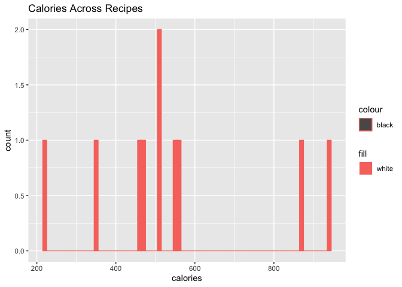

```r
caloriesHistogram <- ggplot(recipes_df, aes(x = calories))
caloriesHistogram + geom_histogram(aes(color="black", fill="white"), binwidth = 10, bins = 10) +
  labs(title = "Calories Across Recipes")
```

*Intepretation:* Calories vary so widely across recipes that it is highly uncommon for more than one recipe to have the same number of calories, especially with such a small sample size. It is recommended that this type of graph not be used on these data in the future. If a histogram is needed for these data consider recoded the number of calories for each recipe into “bins” made up of ranges of calories, this way more recipes fall in each bin. That strategy with larger sample size would make this visual more meaningful. It’s always important to see what doesn’t work though!

#### Scatterplot 1

What if we now wanted to know if there is a relationship between the amount of protein in a recipe and the amount of carbs? A scatterplot can help us do that.

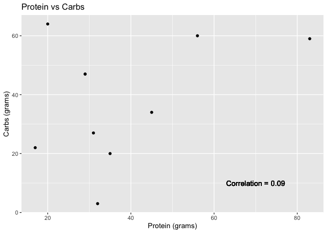

```r
correlationOne <- cor(recipes_df$protein, recipes_df$carbs, method= "spearman")

scatterplotProteinCarbs <- ggplot(recipes_df, aes(x = protein, y = carbs))
scatterplotProteinCarbs + geom_point() +
  labs(title = "Protein vs Carbs", x = "Protein (grams)", y = "Carbs (grams)") +
  geom_text(x = 70, y = 10, size = 4, label = paste0("Correlation = ", round(correlationOne, 2)))
```

*Intepretation:* There is a very weak positive linear relationship between the amount of protein a recipe has and the amount of carbs it has.

#### Scatterplot 2

One may logically expect that a recipe that is high in fat will also be high in calories. Let’s now explore if a relationship exists between these two variables in our data frame. Again, we can use a scatterplot to visually evaluate this relationship.

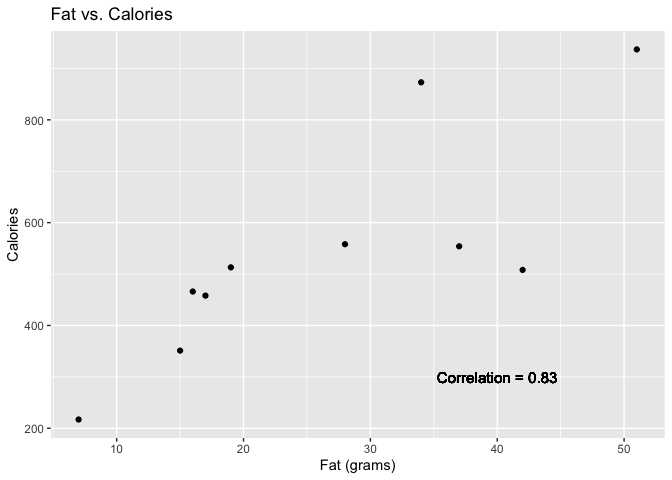

```r
correlationTwo <- cor(recipes_df$fat, recipes_df$calories, method= "spearman")

scatterplotFatCalories <- ggplot(recipes_df, aes(x = fat, y = calories))
scatterplotFatCalories + geom_point() +
  labs(title = "Fat vs. Calories", x = "Fat (grams)", y = "Calories") +
  geom_text(x = 40, y = 300, size = 4, label = paste0("Correlation = ", round(correlationTwo, 2)))
```

*Intepretation:* There is a very strong positive linear relationship between the amount of fat a recipe has and the number of calories in that recipe.

#### Box Plot

What if we wanted to get a more visual sense of the five number summaries for fat, but fat across the levels of calorie rankings in the recipes. That is, how does the distribution of fat vary between recipes that are considered HIGH in calories and recipes considered LOW in calories? A box plot is a great way to do that! Box plots also have the ability to determine if there are any statistical outliers in the distribution of the data.

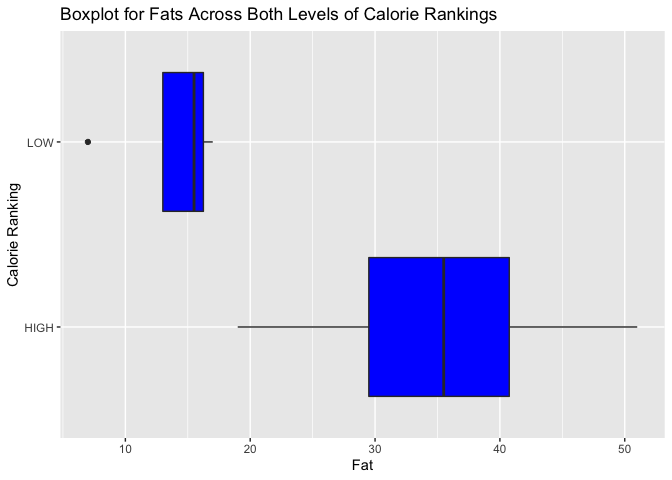

```r
boxPlotFat <- ggplot(recipes_df, aes(x = fat, y = caloriesRanking))
boxPlotFat + geom_boxplot(fill = "blue") +
  labs(title = "Boxplot for Fats Across Both Levels of Calorie Rankings", x= "Fat", y= "Calorie Ranking")
```

#### Bar Plot

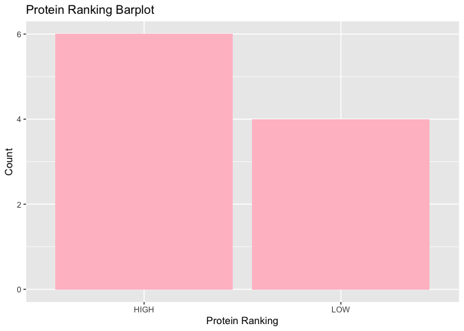

```r
macrosBarPlot <- ggplot(recipes_df, aes(x= proteinRanking))
macrosBarPlot + geom_bar(fill="pink") +
  labs(title = "Protein Ranking Barplot", x= "Protein Ranking", y= "Count")
```

*Intepretation:* There are more recipes in this data frame that are considered HIGH in protein, than LOW in protein. However, it is worth noting that with such a small sample size it is difficult to tell if this pattern is representative of the true rate of proteinRanking in the population of all Greek recipes.

## Wrap Up

To summarize what I did to execute this project:

- I installed and loaded the packages needed for connection, query, and analysis of the spoonacularAPI.
- I then made a connection to the spoonacularAPI and queried the API to return content on multiple criteria of interest. I also saved that content into a more usable data frame for further analysis.
- I then created functions that will allow a user to run their own queries of interest on the spoonacularAPI.
- Finally, I explored the data frame I made using contingency tables, numeric summaries, and graphical displays of categorical and quantitative data.
  - My exploratory analyses generated several interesting findings. The most notable findings were the strong relationship between the amount of fat a recipe had and the number of calories in that recipe. Also interested was the lack of a relationship between protein and carbs. I would have thought that relationship would be at least a bit stronger than it was. This information can be very informative to individuals wanting to better understand the macronutrient breakdown commonly found in Greek recipes. The functions in this documentation can also be easily modified by users wanting to learn about different parameters related to recipes than what I used in the current document.